# A Data Visualization Journey with Seaborn

"Global Insights" is an interactive, data-driven journey designed to provide a comprehensive understanding of various global datasets through the lens of data visualization using Seaborn, a powerful Python library. This course aims to build fundamental skills in data interpretation and visualization, enabling participants to uncover and communicate meaningful patterns and relationships within diverse datasets.

## Explore Datasets

In this course, participants will embark on a series of engaging, real-world scenarios, applying Seaborn to explore and visualize data from multiple perspectives. Each module focuses on a distinct dataset and visualization technique, offering a blend of guided instruction and hands-on practice. The course is structured as follows:

**World Development Indicators Analysis**: Utilizing the `country_data` dataset, participants will create a scatter plot to examine the relationship between GDP and literacy rates, with a focus on regional distinctions. This scenario simulates a data analyst's role in an international development agency, seeking insights to inform policy and investment decisions.

**Automotive Industry Trends**: With the `mpg` dataset, learners will construct a line plot to analyze the evolution of vehicle weights over model years, differentiated by the country of origin. This exercise mirrors a market analyst's task in the automotive sector, exploring historical trends to predict future market shifts.

**Educational Performance Study**: Using `student_data`, the course delves into educational research by creating a box plot to investigate the relationship between academic failures and final grades. This scenario places participants in the role of educational researchers, analyzing factors influencing student performance.

"Global Insights" not only enhances data visualization skills but also fosters critical thinking and storytelling abilities, essential for any aspiring data analyst, researcher, or enthusiast.

## Import Libraries and Datasets

**Preparing the Analytics Workspace**: In a data analysis firm, the first step is setting up the environment with necessary tools and data. This cell accomplishes that by importing essential libraries and datasets.

```python
# Importing essential data analysis and visualization libraries
import pandas as pd
import numpy as np
import matplotlib.pyplot as plt
import seaborn as sns

# Loading various datasets for analysis
country_data = pd.read_csv('datasets/countries-of-the-world.csv', decimal=",")
mpg = pd.read_csv('datasets/mpg.csv')
student_data = pd.read_csv('datasets/student-alcohol-consumption.csv', index_col=0)
survey = pd.read_csv('datasets/young-people-survey-responses.csv', index_col=0)
```

## World Development Indicators Analysis

**Analyzing Global Development Patterns**: A development economist wants to understand how a country's GDP relates to its literacy rate and if there are regional patterns.

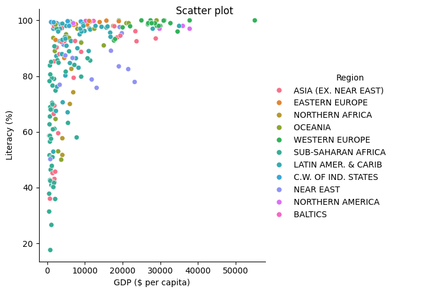

```python
# Visualization of GDP vs Literacy rate segmented by region using a scatter plot

# Create a scatter plot of GDP vs Literacy rate, colored by region, using country_data.
g = sns.relplot(x = 'GDP ($ per capita)',
                y = 'Literacy (%)',
                data = country_data,
                hue='Region',
                kind = 'scatter',)

g.fig.suptitle('Scatter plot')

plt.show()
```

**Insights:**

The plot might reveal that higher GDP countries generally have higher literacy rates.

Regional patterns, such as certain regions having consistently lower GDP and literacy rates, can indicate areas needing attention.